# Lab Report

Kostas Ntagiantas

July 20, 2018

# Datasets

The panel shown below contains 144 melanoma cell lines and 6 normal melanoyctes (2 immortal included) from 4 different experiments querried from GEO. Raw data processed with the RMA algorithm, integrated with ComBat, removing the batch effect caused from the three different platforms.

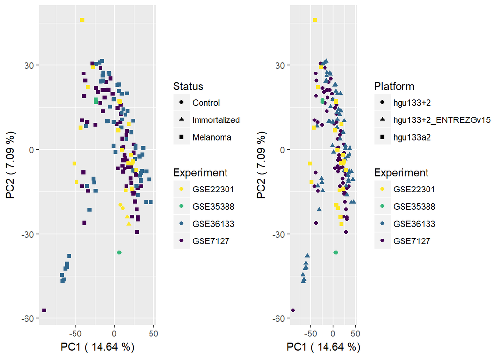

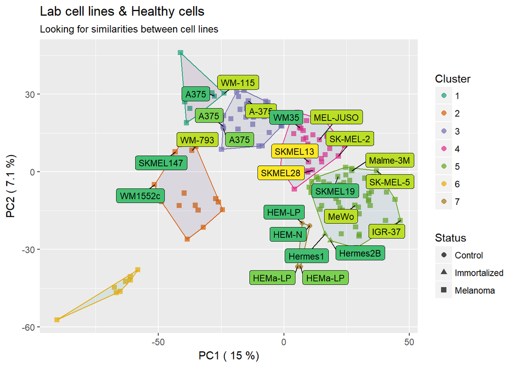

As seen in the plot above, the cell lines that are available in the lab span across most of the space defined by the two main principal components. As a validation of the successful data integration, the healthy controls are close together and close to the immortalized melanocytes, while the four different biological samples of cell lines A-375 are also close together, despite coming from different experiments and platforms.

By the way the cell lines cluster in the PCA space, 7 clusters are defined. It is assumed, that each cluster has biological differences from the others. For this reason, the iterative procedure by which the Differentially Expressed Genes are found is applied in each cluster separately. The cell lines that interest us do not include any in cluster 6 that anyway seems to be an outlier and comes from the HS- family of cell lines (Hs-600T, Hs-688(A)T, Hs-834T, Hs-839T, etc.)

## Lab cell lines in the PCA space of the 144 melanoma cell lines

| Cluster | Cell line |
| --- | --- |
| 1 | WM-115 |
| 1 | A375 |
| 2 | WM-793 |
| 2 | SKMEL147 |
| 2 | WM1552c |
| 3 | A-375 |
| 3 | A375 |
| 3 | A375 |
| 4 | SKMEL13 |
| 4 | SKMEL28 |
| 4 | MEL-JUSO |
| 4 | SK-MEL-2 |
| 4 | WM35 |
| 5 | IGR-37 |
| 5 | Malme-3M |
| 5 | MeWo |
| 5 | SK-MEL-5 |
| 5 | SKMEL19 |

# Differentially expressed genes

| Gene | meanLogFC | Direction | Set |
| --- | --- | --- | --- |
| PMAIP1 | 3.115116 | up | From all |
| RAB33A | -4.475988 | down | From all |
| DPP4 | -3.868831 | down | From all |
| IGFBP3 | 6.698607 | up | From cluster 1 |
| SERPINA3 | 6.451705 | up | From cluster 1 |
| HLA-DRA | 6.220610 | up | From cluster 1 |
| TGFBI | 6.160902 | up | From cluster 1 |
| TSPAN13 | 5.910298 | up | From cluster 1 |
| WNT5A | 5.789012 | up | From cluster 1 |
| PODXL | 5.440707 | up | From cluster 1 |
| PRAME | 5.407255 | up | From cluster 1 |
| TFPI2 | 5.391359 | up | From cluster 1 |
| SFRP1 | 5.193612 | up | From cluster 1 |
| NPTX2 | 4.943387 | up | From cluster 1 |
| CCL2 | 4.873616 | up | From cluster 1 |
| COL15A1 | 4.870366 | up | From cluster 1 |
| S100A4 | 4.759756 | up | From cluster 1 |
| PTX3 | 4.756019 | up | From cluster 1 |
| FGF13 | 4.736892 | up | From cluster 1 |
| TMEM47 | 4.637282 | up | From cluster 1 |
| NFE2L3 | 4.606214 | up | From cluster 1 |
| MGP | 4.584174 | up | From cluster 1 |
| ITIH5 | 4.524356 | up | From cluster 1 |
| COL9A3 | 4.516855 | up | From cluster 1 |
| FST | 4.506094 | up | From cluster 1 |
| KCNN4 | 4.498262 | up | From cluster 1 |
| CD74 | 4.441470 | up | From cluster 1 |
| TNC | 4.384479 | up | From cluster 1 |
| FLRT3 | 4.374426 | up | From cluster 1 |
| EFEMP1 | 4.344328 | up | From cluster 1 |

[output cut: 1511 more lines]

The differentially expressed genes that are used in the cMap tool to find drugs with similar/oposite signature are found through an iterative process: for every cluster, 6 melanoma samples are randomly selected and then differential gene analysis is conducted against the 6 normal melanocytes. This process is repeated 1000 times and then the genes are selected that are differentially expressed in at least 800 of the 1000 simulations.

As we are interested only in the cell lines available in the lab, cluster 6 is left out of this analysis as is contains none of these cell lines.

The results are stored in the table below. You can copy them in the *Query* tool of *cMap* and get results to find compounds.

Differentially expressed genes in clusters 1-2-3

| Direction | Gene |
| --- | --- |
| down | APH1B |
| down | APOLD1 |
| down | AVPI1 |
| down | BDH2 |
| down | CA14 |
| down | CAB39L |
| down | CACNA1A |
| down | CELF2 |
| down | CITED1 |
| down | CPPED1 |
| down | DAB2 |
| down | DCLK1 |
| down | DEXI |
| down | DPP4 |
| down | FBXL2 |
| down | FEM1B |
| down | FIG4 |
| down | FKBP1B |
| down | FXYD6 |
| down | GAPDHS |
| down | GK |
| down | GMPR |
| down | GNAL |
| down | GPR137B |
| down | GPR143 |
| down | HCG4 |
| down | HPGD |
| down | HRK |
| down | IDI2-AS1 |
| down | IL12RB2 |

[output cut: 79 more lines]

Differentially expressed genes in clusters 4-5

| Direction | Gene |
| --- | --- |
| down | AK5 |
| down | ALCAM |
| down | APH1B |
| down | ARL4C |
| down | BST1 |
| down | C14orf132 |
| down | CACNA1A |
| down | CD59 |
| down | CDH3 |
| down | CITED1 |
| down | COL5A2 |
| down | CPPED1 |
| down | DOK5 |
| down | DPP4 |
| down | EFHD1 |
| down | FABP3 |
| down | FBN1 |
| down | FBXL2 |
| down | FEZ1 |
| down | FXYD6 |
| down | GMPR |
| down | HNMT |
| down | KCNJ13 |
| down | KIT |
| down | LRRC2 |
| down | MAP4K3 |
| down | MARCKS |
| down | MFSD12 |
| down | MICAL1 |
| down | MYO1D |

[output cut: 86 more lines]

## Analysis of the lab cells

Focusing on the lab cells, the first step is to build a positive control, to be able to compare downstream with the rest of the lines.The A-375 cell line is selected for the role of the positive control, as there are 4 samples available coming from three different experiments, and also because of the importance and abundancy of the line in many experiments and citations.

Differentially expressed genes in A375

| Direction | Gene | logFC | adj.P.Val |
| --- | --- | --- | --- |
| down | COL11A1 | -6.292629 | 0.0000155 |
| down | MME | -6.090855 | 0.0000155 |
| down | MLPH | -4.752795 | 0.0000155 |
| down | DCT | -7.710150 | 0.0000155 |
| down | AK5 | -4.255444 | 0.0000155 |
| down | CITED1 | -3.827303 | 0.0000155 |
| down | TSPYL5 | -3.977768 | 0.0000155 |
| down | HSPA2 | -3.643359 | 0.0000155 |
| down | PRUNE2 | -4.437025 | 0.0000160 |
| down | ASPA | -5.230078 | 0.0000168 |
| down | KIT | -6.489350 | 0.0000227 |
| down | MYC | -3.246023 | 0.0000239 |
| down | GMPR | -6.548192 | 0.0000246 |
| down | OLFM1 | -3.107559 | 0.0000273 |
| down | PROS1 | -3.521929 | 0.0000273 |
| down | NME5 | -3.267428 | 0.0000273 |
| down | RAB33A | -5.721955 | 0.0000273 |
| down | RGS20 | -3.149175 | 0.0000273 |
| down | APOLD1 | -5.854090 | 0.0000292 |
| down | C2CD2 | -4.011379 | 0.0000318 |
| down | SELENBP1 | -4.658625 | 0.0000318 |
| down | ST6GALNAC2 | -5.958737 | 0.0000318 |
| down | MARCKS | -2.984027 | 0.0000320 |
| down | ESRP1 | -5.167093 | 0.0000335 |
| down | CAPN3 | -7.281245 | 0.0000335 |
| down | MYO10 | -4.102590 | 0.0000339 |
| down | GYG2 | -3.249136 | 0.0000354 |
| down | CYBRD1 | -2.688875 | 0.0000364 |
| down | SNAI2 | -4.387233 | 0.0000391 |
| down | RAB27A | -3.721244 | 0.0000394 |

[output cut: 417 more lines]

The rest of the lab cell lines along with the positive control are then clustered together to contrast with the healthy samples and find a gene signature for every cluster.

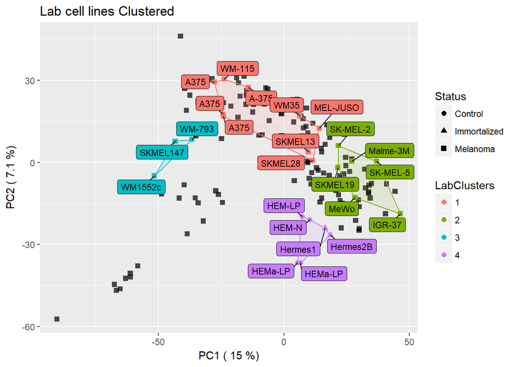

Differentially expressed genes in Lab cluster 1

| Direction | Gene | logFC | adj.P.Val |
| --- | --- | --- | --- |
| down | RAB33A | -5.287762 | 0.0000000 |
| down | KIT | -5.455848 | 0.0000018 |
| down | PRUNE2 | -4.151031 | 0.0000018 |
| down | DPP4 | -4.391568 | 0.0000032 |
| down | CA14 | -3.529987 | 0.0000037 |
| down | WFDC1 | -6.734610 | 0.0000059 |
| down | KDM5D | -3.550075 | 0.0000081 |
| down | EIF1AY | -4.328162 | 0.0000401 |
| down | LRRC2 | -2.405107 | 0.0000789 |
| down | SELENBP1 | -3.886631 | 0.0000897 |
| down | GNAL | -2.856663 | 0.0000998 |
| down | OPTN | -3.029988 | 0.0001079 |
| down | DDX3Y | -3.126543 | 0.0001170 |
| down | STAM | -1.683541 | 0.0001170 |
| down | OCA2 | -4.459000 | 0.0001205 |
| down | ZBED1 | -1.270108 | 0.0001257 |
| down | PGRMC2 | -2.063229 | 0.0001305 |
| down | THBD | -3.095353 | 0.0001343 |
| down | RHOBTB1 | -2.722875 | 0.0001410 |
| down | MXRA7 | -1.583494 | 0.0002534 |
| down | HPGD | -2.877912 | 0.0002650 |
| down | NFIL3 | -1.675882 | 0.0004002 |
| down | DOK5 | -3.051763 | 0.0004280 |
| down | OXCT1 | -1.301278 | 0.0004280 |
| down | FBXL2 | -1.884308 | 0.0005231 |
| down | EPS15 | -1.447846 | 0.0006148 |
| down | KCNJ13 | -1.884983 | 0.0007028 |
| down | MICAL1 | -2.373393 | 0.0007028 |
| down | LONRF1 | -2.359134 | 0.0007028 |
| down | BDH2 | -1.469322 | 0.0007028 |

[output cut: 729 more lines]

Differentially expressed genes in Lab cluster 2

| Direction | Gene | logFC | adj.P.Val |
| --- | --- | --- | --- |
| down | AK5 | -3.856424 | 0.0002712 |
| down | PKD2 | -2.222685 | 0.0003425 |
| down | TSPAN5 | -1.949783 | 0.0003533 |
| down | TRPM4 | -2.158663 | 0.0010671 |
| down | DPP4 | -3.765277 | 0.0011249 |
| down | FEZ1 | -2.409630 | 0.0018675 |
| down | LRRC2 | -2.289465 | 0.0022414 |
| down | FBN1 | -2.318653 | 0.0022414 |
| down | DOK5 | -3.214212 | 0.0027537 |
| down | SYNC | -3.351518 | 0.0027537 |
| down | EFHD1 | -2.547273 | 0.0027537 |
| down | SRGN | -2.499516 | 0.0030376 |
| down | ECHDC2 | -1.988527 | 0.0034558 |
| down | CPPED1 | -1.553108 | 0.0034608 |
| down | PPARG | -1.703433 | 0.0040522 |
| down | SLC16A5 | -1.561877 | 0.0040522 |
| down | NTF3 | -2.195516 | 0.0040522 |
| down | RAB31 | -2.163810 | 0.0040522 |
| down | HSPB2 | -2.752936 | 0.0040522 |
| down | P2RX7 | -2.665363 | 0.0040522 |
| down | CD59 | -1.263999 | 0.0040522 |
| down | SUSD5 | -3.005624 | 0.0049394 |
| down | BST1 | -2.581566 | 0.0049742 |
| down | COL5A2 | -4.207253 | 0.0050195 |
| down | FAP | -3.961120 | 0.0055052 |
| down | ARL4C | -2.383871 | 0.0056934 |
| down | OPTN | -2.543493 | 0.0060519 |
| down | CAB39L | -1.037626 | 0.0084346 |
| down | IFITM2 | -2.901671 | 0.0084346 |
| down | CD36 | -3.044145 | 0.0085072 |

[output cut: 319 more lines]

Differentially expressed genes in Lab cluster 3

| Direction | Gene | logFC | adj.P.Val |
| --- | --- | --- | --- |
| down | GMPR | -5.384672 | 0.0000086 |
| down | OCA2 | -6.505722 | 0.0000098 |
| down | TYRP1 | -8.691754 | 0.0000125 |
| down | ESRP1 | -4.974256 | 0.0000159 |
| down | TYR | -7.232498 | 0.0000169 |
| down | TNFRSF14 | -3.657150 | 0.0000188 |
| down | CELF2 | -4.451638 | 0.0000227 |
| down | PLXNC1 | -4.577610 | 0.0000268 |
| down | CITED1 | -4.286556 | 0.0000268 |
| down | GYG2 | -2.977019 | 0.0000292 |
| down | WFDC1 | -6.979437 | 0.0000469 |
| down | NME5 | -2.712828 | 0.0000541 |
| down | RAB33A | -5.055946 | 0.0000857 |
| down | PRUNE2 | -4.155483 | 0.0001022 |
| down | SERINC5 | -2.917063 | 0.0001184 |
| down | OLFM1 | -2.829822 | 0.0001195 |
| down | ID4 | -2.896587 | 0.0001308 |
| down | P2RX7 | -4.016121 | 0.0001510 |
| down | KIT | -4.905556 | 0.0002310 |
| down | PROS1 | -4.711403 | 0.0002401 |
| down | RAB38 | -5.287686 | 0.0003010 |
| down | COL11A1 | -5.785036 | 0.0003301 |
| down | MYO10 | -2.653102 | 0.0003301 |
| down | TBC1D16 | -3.206948 | 0.0003432 |
| down | OSTM1 | -2.785765 | 0.0003750 |
| down | HCG4 | -2.815238 | 0.0003790 |
| down | FEZ1 | -2.816929 | 0.0003808 |
| down | VAMP8 | -5.152122 | 0.0004343 |
| down | MLANA | -7.634971 | 0.0004607 |
| down | MEGF9 | -1.840282 | 0.0005370 |

[output cut: 692 more lines]

# Connectivity Map results

By inserting the above genes in the Query tool of the Connectivity map we get the compounds which could potentially reverse the signature of the cell, serving as a treatment.

The only cell line selected from cMap is A-375 as it is the only melanoma cell line provided. The four tables below only contain compounds that have a maximum of -95 correlation with the signature that was queried, as those are considered the most promising results.

A375 reverse signature

| name | description | target | belongs_to | A-375 |
| --- | --- | --- | --- | --- |
| Bromodomain Inhibitor |  |  |  | -99.46 |
| atenolol | adrenergic receptor antagonist | ADRB1, ADRB2 |  | -99.45 |
| efavirenz | HIV reverse transcriptase inhibitor, non-nucleoside reverse transcriptase inhibitor, reverse transcriptase inhibitor | CYP2B6, CYP2C19, CYP2C8, CYP3A4, CYP3A5 |  | -99.32 |
| AG-490 | epidermal growth factor receptor (EGFR) inhibitor, ErbB2 and JAK2 inhibitor, JAK inhibitor | JAK2, JAK3, EGFR, STAT3 |  | -99.27 |
| 3-matida | glutamate receptor antagonist | GRM1 |  | -99.11 |
| SB-590885 | RAF inhibitor | BRAF | RAF inhibitor | -99.1 |
| JAK inhibitor |  |  |  | -99.06 |
| bisindolylmaleimide | CDK inhibitor, PKC inhibitor, leucine rich repeat kinase inhibitor | CCND1, CDK4, LRRK2, PDPK1, PIM1, PRKCA, PRKCB, PRKCI, PRKCZ |  | -98.98 |
| SB-202190 | p38 MAPK inhibitor, interleukin inhibitor, stress activated protein kinase inhibitor | MAPK14, AKT1, ALOX5, CHEK1, GSK3B, LCK, MAPK1, MAPK11, MAPK12, MAPK8, PRKCA, ROCK1, RPS6KB1, SGK1 | Bromodomain Inhibitor, P38 MAPK inhibitor | -98.88 |
| NVP-AUY922 | HSP inhibitor | HSP90AA1, HSP90AA2, HSP90AB1 | HSP inhibitor | -98.85 |
| BI-2536 | PLK inhibitor, apoptosis stimulant, cell cycle inhibitor, protein kinase inhibitor | PLK1, BRD4, PLK2, PLK3 | Bromodomain Inhibitor | -98.83 |
| PF-543 | sphingosine kinase inhibitor | SPHK1 |  | -98.79 |
| nimodipine | calcium channel blocker, L-type calcium channel blocker | CACNA1C, NR3C2, AHR, CACNA1D, CACNA1F, CACNA1S, CACNB1, CACNB2, CACNB3, CACNB4, CFTR |  | -98.71 |
| deltaline | acetylcholine receptor antagonist | CHRNA7 |  | -98.63 |
| azacyclonol | ataractive drug used to diminish hallucinations | HRH1 |  | -98.56 |
| TG-101348 | JAK inhibitor, FLT3 inhibitor, RET tyrosine kinase inhibitor | JAK2, FLT3, BRD4, JAK1, JAK3, RET, TYK2 | Bromodomain Inhibitor, FLT3 inhibitor, JAK inhibitor | -98.55 |
| STO-609 | calcium/calmodulin dependent protein kinase inhibitor, calmodulin inhibitor | CAMKK1, CAMKK2 |  | -98.55 |
| tetrahydropalmatine | serotonin release inhibitor |  |  | -98.37 |
| BIBU-1361 | EGFR inhibitor | EGFR | EGFR inhibitor | -98.34 |
| PKC inhibitor |  |  |  | -98.28 |
| MG-132 | proteasome inhibitor | PSMB1 | Proteasome inhibitor | -98.28 |
| midostaurin | FLT3 inhibitor, KIT inhibitor, PKC inhibitor, angiogenesis inhibitor, cell cycle inhibitor, cyclin inhibitor, histamine release inhibitor, multi targeted kinase inhibitor, PDGFR tyrosine kinase recept… | FLT3, KIT, CCNB1, FLT1, KDR, PDGFRB, PRKCA, PRKCG, VEGFA | FLT3 inhibitor, PDGFR/KIT inhibitor, PKC inhibitor, VEGFR inhibitor | -98.22 |
| eriochrome-black-t | azo dye used in titrations to detect metal ions |  |  | -98.16 |
| FLT3 inhibitor |  |  |  | -98.15 |
| givinostat | HDAC inhibitor, interleukin receptor antagonist, interleukin synthesis inhibitor, tumor necrosis factor receptor antagonist, tumor necrosis factor release inhibitor | HDAC2, HDAC1, HDAC3, HDAC4, HDAC5, HDAC6, HDAC7, HDAC8, HDAC9, IL1B, IL1R2, IL6R, TNF | HDAC inhibitor | -98.12 |
| benzatropine | anticholinergic | CHRM1, HRH1, SLC6A3 |  | -98.09 |
| U-0126 | MEK inhibitor, JAK inhibitor, MAP kinase inhibitor | AKT1, CHEK1, GSK3B, JAK2, LCK, MAP2K1, MAP2K2, MAP2K7, MAPK1, MAPK11, MAPK12, MAPK14, MAPK8, PRKCA, RAF1, ROCK1, RPS6KB1, SGK1 | MEK inhibitor | -97.99 |
| FOS transcription factor family GOF |  |  |  | -97.95 |
| PU-H71 | HSP inhibitor | HSP90AA1 | HSP inhibitor | -97.68 |
| isoreserpine | vesicular monoamine transporter inhibitor | SLC18A2, SLC18A1, SIAH1 |  | -97.44 |

[output cut: 183 more lines]

Cluster 1 reverse signature

| name | description | target | belongs_to | median_score | Score | Case_studied | cell_line |
| --- | --- | --- | --- | --- | --- | --- | --- |
| AG-490 | epidermal growth factor receptor (EGFR) inhibitor, ErbB2 and JAK2 inhibitor, JAK inhibitor | JAK2, JAK3, EGFR, STAT3 |  | -28.21 | -99.98 | Cluster 1 | A375 |
| HG-5-113-01 | protein kinase inhibitor | ABL1, LTK, STK10 |  | -92.62 | -99.86 | Cluster 1 | A375 |
| BIBU-1361 | EGFR inhibitor | EGFR | EGFR inhibitor | -98.49 | -99.85 | Cluster 1 | A375 |
| Bromodomain Inhibitor |  |  |  | -96.37 | -99.83 | Cluster 1 | A375 |
| TG-101348 | JAK inhibitor, FLT3 inhibitor, RET tyrosine kinase inhibitor | JAK2, FLT3, BRD4, JAK1, JAK3, RET, TYK2 | Bromodomain Inhibitor, FLT3 inhibitor, JAK inhibitor | -98.10 | -99.81 | Cluster 1 | A375 |
| BMS-536924 | insulin growth factor receptor inhibitor, insulin receptor ligand | IGF1R, AKT1, CCNE1, CDK2, CYP3A4, ERBB2, INSR, KDR, LCK, MAPK1, MET, PDGFRA, PDGFRB | IGF-1 inhibitor | -94.26 | -99.8 | Cluster 1 | A375 |
| BI-2536 | PLK inhibitor, apoptosis stimulant, cell cycle inhibitor, protein kinase inhibitor | PLK1, BRD4, PLK2, PLK3 | Bromodomain Inhibitor | -96.97 | -99.79 | Cluster 1 | A375 |
| JAK inhibitor |  |  |  | -88.03 | -99.75 | Cluster 1 | A375 |
| selumetinib | MEK inhibitor, MAP kinase inhibitor | MAP2K1, MAP2K2 | MEK inhibitor | -98.17 | -99.74 | Cluster 1 | A375 |
| GDC-0879 | RAF inhibitor | BRAF | RAF inhibitor | -24.63 | -99.72 | Cluster 1 | A375 |
| KU-0060648 | DNA dependent protein kinase, DNA dependent protein kinase inhibitor, PI3K inhibitor | PIK3CA, PIK3CB, PIK3CD, PIK3CG, PRKDC | DNA dependent protein kinase inhibitor, PI3K inhibitor | -97.72 | -99.72 | Cluster 1 | A375 |
| RO-3306 | CDK inhibitor | CDK1 | CDK inhibitor | -71.30 | -99.69 | Cluster 1 | A375 |
| PLX-4720 | RAF inhibitor | BRAF, KDR | RAF inhibitor | 65.86 | -99.67 | Cluster 1 | A375 |
| AS-605240 | Phosphatidylinositol 3-kinase (PI3K) inhibitor, PI3K inhibitor | MAOB, PIK3CA, PIK3CB, PIK3CD, PIK3CG | PI3K inhibitor | -91.92 | -99.63 | Cluster 1 | A375 |
| tivozanib | VEGFR inhibitor, KIT inhibitor, tyrosine kinase inhibitor | FLT1, FLT4, KDR, KIT, PDGFRA, PDGFRB | PDGFR/KIT inhibitor, VEGFR inhibitor | -93.77 | -99.6 | Cluster 1 | A375 |
| tozasertib | Aurora kinase inhibitor, Bcr-Abl kinase inhibitor, FLT3 inhibitor, JAK inhibitor, Abl kinase inhibitor, mitotic inhibitor | AURKA, AURKB, ABL1, AURKC, BCR, FLT3, JAK2, DDR2, LCK |  | -96.63 | -99.58 | Cluster 1 | A375 |
| SB-202190 | p38 MAPK inhibitor, interleukin inhibitor, stress activated protein kinase inhibitor | MAPK14, AKT1, ALOX5, CHEK1, GSK3B, LCK, MAPK1, MAPK11, MAPK12, MAPK8, PRKCA, ROCK1, RPS6KB1, SGK1 | Bromodomain Inhibitor, P38 MAPK inhibitor | -82.81 | -99.55 | Cluster 1 | A375 |
| L-690488 | nositol monophosphatase inhibitor | IMPA1 |  | -58.50 | -99.53 | Cluster 1 | A375 |
| NVP-TAE684 | ALK tyrosine kinase receptor inhibitor, ALK tyrosine kinase receptor mutant inhibitor, leucine rich repeat kinase inhibitor | ALK, INSR |  | -93.72 | -99.52 | Cluster 1 | A375 |
| aminopurvalanol-a | CDK inhibitor, tyrosine kinase inhibitor | CDK1, CDK2, CDK5, CDK6 | CDK inhibitor | -87.58 | -99.49 | Cluster 1 | A375 |
| pirarubicin | topoisomerase inhibitor | TOP2A | Topoisomerase inhibitor | -88.19 | -99.48 | Cluster 1 | A375 |
| doxorubicin | topoisomerase inhibitor, DNA intercalating drug | TOP2A | Topoisomerase inhibitor | -93.94 | -99.46 | Cluster 1 | A375 |
| trichostatin-a | HDAC inhibitor, CDK expression enhancer, ID1 expression inhibitor | HDAC7, HDAC8, HDAC1, HDAC10, HDAC2, HDAC3, HDAC4, HDAC5, HDAC6, HDAC9 |  | -75.69 | -99.42 | Cluster 1 | A375 |
| SB-590885 | RAF inhibitor | BRAF | RAF inhibitor | -88.08 | -99.4 | Cluster 1 | A375 |
| RAF inhibitor |  |  |  | -71.83 | -99.39 | Cluster 1 | A375 |
| givinostat | HDAC inhibitor, interleukin receptor antagonist, interleukin synthesis inhibitor, tumor necrosis factor receptor antagonist, tumor necrosis factor release inhibitor | HDAC2, HDAC1, HDAC3, HDAC4, HDAC5, HDAC6, HDAC7, HDAC8, HDAC9, IL1B, IL1R2, IL6R, TNF | HDAC inhibitor | -19.59 | -99.37 | Cluster 1 | A375 |
| NCH-51 | HDAC inhibitor | HDAC1, HDAC10, HDAC11, HDAC2, HDAC3, HDAC4, HDAC5, HDAC6, HDAC7, HDAC8, HDAC9 | HDAC inhibitor | -58.40 | -99.36 | Cluster 1 | A375 |
| scriptaid | HDAC inhibitor | HDAC1, HDAC2, HDAC3, HDAC4, HDAC5, HDAC6, HDAC7, HDAC8, HDAC9 | HDAC inhibitor | -48.70 | -99.32 | Cluster 1 | A375 |
| IKK-16 | IKK inhibitor | IKBKB | IKK inhibitor | -81.35 | -99.29 | Cluster 1 | A375 |
| TWS-119 | glycogen synthase kinase inhibitor | GSK3B, JUN, MYC | Glycogen synthase kinase inhibitor | 0.00 | -99.21 | Cluster 1 | A375 |

[output cut: 112 more lines]

Cluster 2 reverse signature

| name | description | target | belongs_to | median_score | Score | Case_studied | cell_line |
| --- | --- | --- | --- | --- | --- | --- | --- |
| MK-2206 | AKT inhibitor | AKT1, AKT2, AKT3 |  | -97.29 | -99.89 | Cluster 2 | A375 |
| BIBU-1361 | EGFR inhibitor | EGFR | EGFR inhibitor | -98.49 | -99.88 | Cluster 2 | A375 |
| serdemetan | MDM inhibitor, angiogenesis stimulant, apoptosis stimulant, oncogene inhibitor | MDM2 |  | -83.76 | -99.8 | Cluster 2 | A375 |
| GDC-0879 | RAF inhibitor | BRAF | RAF inhibitor | -24.63 | -99.74 | Cluster 2 | A375 |
| selumetinib | MEK inhibitor, MAP kinase inhibitor | MAP2K1, MAP2K2 | MEK inhibitor | -98.17 | -99.72 | Cluster 2 | A375 |
| thioridazine | acetylcholine receptor ligand, dopamine receptor, dopamine receptor antagonist, mucosa associated lymphoid tissue lymphoma translocation protein 1 (MALT1) inhibitor | DRD1, DRD2, HTR2A, ADRA1A, ADRA1B, CHRNA7, DRD5, HRH1, HTR1A, HTR2C, HTR6, HTR7, KCNH2, MALT1 | Dopamine receptor antagonist | -80.35 | -99.69 | Cluster 2 | A375 |
| AS-605240 | Phosphatidylinositol 3-kinase (PI3K) inhibitor, PI3K inhibitor | MAOB, PIK3CA, PIK3CB, PIK3CD, PIK3CG | PI3K inhibitor | -91.92 | -99.65 | Cluster 2 | A375 |
| PLX-4720 | RAF inhibitor | BRAF, KDR | RAF inhibitor | 65.86 | -99.61 | Cluster 2 | A375 |
| BMS-536924 | insulin growth factor receptor inhibitor, insulin receptor ligand | IGF1R, AKT1, CCNE1, CDK2, CYP3A4, ERBB2, INSR, KDR, LCK, MAPK1, MET, PDGFRA, PDGFRB | IGF-1 inhibitor | -94.26 | -99.61 | Cluster 2 | A375 |
| BI-2536 | PLK inhibitor, apoptosis stimulant, cell cycle inhibitor, protein kinase inhibitor | PLK1, BRD4, PLK2, PLK3 | Bromodomain Inhibitor | -96.97 | -99.55 | Cluster 2 | A375 |
| berbamine | calmodulin antagonist | CALM1 | Calmodulin antagonist | -74.45 | -99.51 | Cluster 2 | A375 |
| tozasertib | Aurora kinase inhibitor, Bcr-Abl kinase inhibitor, FLT3 inhibitor, JAK inhibitor, Abl kinase inhibitor, mitotic inhibitor | AURKA, AURKB, ABL1, AURKC, BCR, FLT3, JAK2, DDR2, LCK |  | -96.63 | -99.49 | Cluster 2 | A375 |
| PU-H71 | HSP inhibitor | HSP90AA1 | HSP inhibitor | -63.40 | -99.45 | Cluster 2 | A375 |
| atorvastatin | HMGCR inhibitor, dipeptidyl peptidase inhibitor, tumor necrosis factor expression inhibitor | HMGCR, DPP4, AHR, CYP3A5, FASLG | HMGCR inhibitor | -85.00 | -99.45 | Cluster 2 | A375 |
| triptolide | RNA polymerase inhibitor | CYP2C19, RELA |  | -92.97 | -99.45 | Cluster 2 | A375 |
| BRD-K77681376 | casein kinase inhibitor, FLT3 inhibitor |  |  | -78.80 | -99.4 | Cluster 2 | A375 |
| dihydroergocristine | adrenergic receptor antagonist, prolactin inhibitor, adrenergic receptor partial agonist, dopamine receptor agonist, dopamine receptor partial agonist, dopamine receptor partial antagonist, serotonin … | HTR2A, ADRA1A, ADRB1, DRD1, DRD2, DRD3, DRD4, DRD5, HTR1A, HTR3A, HTR4, HTR5A, HTR6, HTR7 |  | -66.50 | -99.39 | Cluster 2 | A375 |
| pirarubicin | topoisomerase inhibitor | TOP2A | Topoisomerase inhibitor | -88.19 | -99.37 | Cluster 2 | A375 |
| daunorubicin | RNA synthesis inhibitor, topoisomerase inhibitor, DNA synthesis inhibitor, radical formation stimulant | TOP2A, TOP2B |  | -94.46 | -99.35 | Cluster 2 | A375 |
| trifluoperazine | breast cancer resistance protein inhibitor, calcium/calmodulin dependent protein kinase inhibitor, dopamine receptor, dopamine receptor antagonist, sodium channel blocker | DRD2, ABCG2, ADRA1A, CALM1, CALY, CAMK2A, DRD4, HRH1, HTR2A, HTR2C, S100A4, SCN4A, SCN9A, TNNC1 | Dopamine receptor antagonist | -70.32 | -99.3 | Cluster 2 | A375 |
| GW-5074 | RAF inhibitor, leucine rich repeat kinase inhibitor | LRRK1, LRRK2, NTRK1, RAF1 | RAF inhibitor | 0.00 | -99.29 | Cluster 2 | A375 |
| pidorubicine | topoisomerase inhibitor, DNA intercalating drug | TOP2A | Topoisomerase inhibitor | -92.33 | -99.25 | Cluster 2 | A375 |
| doxorubicin | topoisomerase inhibitor, DNA intercalating drug | TOP2A | Topoisomerase inhibitor | -93.94 | -99.2 | Cluster 2 | A375 |
| sirolimus | mTOR inhibitor, CCR expression inhibitor, cell cycle inhibitor, proteasome inhibitor, protein kinase inhibitor, T cell inhibitor | MTOR, FKBP1A, CCR5, FGF2 |  | -79.00 | -99.04 | Cluster 2 | A375 |
| HG-5-113-01 | protein kinase inhibitor | ABL1, LTK, STK10 |  | -92.62 | -99 | Cluster 2 | A375 |
| BRD-K06956503 | glucosylceramidase inhibitor | GBA |  | -41.59 | -98.95 | Cluster 2 | A375 |
| tivozanib | VEGFR inhibitor, KIT inhibitor, tyrosine kinase inhibitor | FLT1, FLT4, KDR, KIT, PDGFRA, PDGFRB | PDGFR/KIT inhibitor, VEGFR inhibitor | -93.77 | -98.9 | Cluster 2 | A375 |
| dihydroergocristine | adrenergic receptor antagonist, prolactin inhibitor, adrenergic receptor partial agonist, dopamine receptor agonist, dopamine receptor partial agonist, dopamine receptor partial antagonist, serotonin … | HTR2A, ADRA1A, ADRB1, DRD1, DRD2, DRD3, DRD4, DRD5, HTR1A, HTR3A, HTR4, HTR5A, HTR6, HTR7 |  | -34.33 | -98.89 | Cluster 2 | A375 |
| cyclopamine | smoothened receptor antagonist, hedgehog pathway inhibitor | SMO, DHH, IHH, PTCH1 |  | -45.99 | -98.89 | Cluster 2 | A375 |
| AKT-inhibitor-1-2 | AKT inhibitor, PI3K inhibitor | AKT1, AKT2, AKT3 |  | -83.02 | -98.87 | Cluster 2 | A375 |

[output cut: 86 more lines]

Cluster 3 reverse signature

| name | description | target | belongs_to | median_score | Score | Case_studied | cell_line |
| --- | --- | --- | --- | --- | --- | --- | --- |
| IB-MECA | adenosine receptor agonist, granulocyte colony stimulating factor agonist | ADORA3, ADORA1, ADORA2A, ADORA2B | Adenosine receptor agonist | 0.00 | -99.94 | Cluster 3 | A375 |
| SB-202190 | p38 MAPK inhibitor, interleukin inhibitor, stress activated protein kinase inhibitor | MAPK14, AKT1, ALOX5, CHEK1, GSK3B, LCK, MAPK1, MAPK11, MAPK12, MAPK8, PRKCA, ROCK1, RPS6KB1, SGK1 | Bromodomain Inhibitor, P38 MAPK inhibitor | -82.81 | -99.93 | Cluster 3 | A375 |
| dobutamine | adrenergic receptor agonist | ADRB1, ADRB2, ADRA1A | Beta-adrenergic receptor agonist | 0.00 | -99.82 | Cluster 3 | A375 |
| nimodipine | calcium channel blocker, L-type calcium channel blocker | CACNA1C, NR3C2, AHR, CACNA1D, CACNA1F, CACNA1S, CACNB1, CACNB2, CACNB3, CACNB4, CFTR |  | 6.70 | -99.74 | Cluster 3 | A375 |
| tipifarnib-P2 | farnesyltransferase inhibitor, angiogenesis inhibitor, apoptosis stimulant | FNTA, FNTB |  | -70.88 | -99.68 | Cluster 3 | A375 |
| GDC-0879 | RAF inhibitor | BRAF | RAF inhibitor | -24.63 | -99.66 | Cluster 3 | A375 |
| AG-490 | epidermal growth factor receptor (EGFR) inhibitor, ErbB2 and JAK2 inhibitor, JAK inhibitor | JAK2, JAK3, EGFR, STAT3 |  | -28.21 | -99.66 | Cluster 3 | A375 |
| U-0126 | MEK inhibitor, JAK inhibitor, MAP kinase inhibitor | AKT1, CHEK1, GSK3B, JAK2, LCK, MAP2K1, MAP2K2, MAP2K7, MAPK1, MAPK11, MAPK12, MAPK14, MAPK8, PRKCA, RAF1, ROCK1, RPS6KB1, SGK1 | MEK inhibitor | -95.11 | -99.65 | Cluster 3 | A375 |
| PD-184352 | MEK inhibitor, MAP kinase inhibitor | MAP2K1, MAP2K2, MAP3K1, MAP3K2 | MEK inhibitor | -89.40 | -99.63 | Cluster 3 | A375 |
| cimaterol | adrenergic receptor agonist |  | Beta-adrenergic receptor agonist | 23.05 | -99.62 | Cluster 3 | A375 |
| MEK1-2-inhibitor | MEK inhibitor | MAP2K1, MAP2K2 | MEK inhibitor | -80.50 | -99.61 | Cluster 3 | A375 |
| MEK inhibitor |  |  |  | -90.79 | -99.54 | Cluster 3 | A375 |
| PLX-4720 | RAF inhibitor | BRAF, KDR | RAF inhibitor | 65.86 | -99.46 | Cluster 3 | A375 |
| RAF inhibitor |  |  |  | -71.83 | -99.42 | Cluster 3 | A375 |
| AS-605240 | Phosphatidylinositol 3-kinase (PI3K) inhibitor, PI3K inhibitor | MAOB, PIK3CA, PIK3CB, PIK3CD, PIK3CG | PI3K inhibitor | -91.92 | -99.4 | Cluster 3 | A375 |
| RO-15-4513 | GABA benzodiazepine site receptor inverse agonist | GABRA1, GABRA2, GABRA3, GABRA5, GABRA4, GABRA6, GABRB2, GABRG2 |  | 0.00 | -99.39 | Cluster 3 | A375 |
| benzatropine | anticholinergic | CHRM1, HRH1, SLC6A3 |  | -45.41 | -99.39 | Cluster 3 | A375 |
| bisindolylmaleimide | CDK inhibitor, PKC inhibitor, leucine rich repeat kinase inhibitor | CCND1, CDK4, LRRK2, PDPK1, PIM1, PRKCA, PRKCB, PRKCI, PRKCZ |  | -77.59 | -99.37 | Cluster 3 | A375 |
| pirarubicin | topoisomerase inhibitor | TOP2A | Topoisomerase inhibitor | -88.19 | -99.36 | Cluster 3 | A375 |
| tivozanib | VEGFR inhibitor, KIT inhibitor, tyrosine kinase inhibitor | FLT1, FLT4, KDR, KIT, PDGFRA, PDGFRB | PDGFR/KIT inhibitor, VEGFR inhibitor | -93.77 | -99.34 | Cluster 3 | A375 |
| GW-5074 | RAF inhibitor, leucine rich repeat kinase inhibitor | LRRK1, LRRK2, NTRK1, RAF1 | RAF inhibitor | 0.00 | -99.28 | Cluster 3 | A375 |
| TWS-119 | glycogen synthase kinase inhibitor | GSK3B, JUN, MYC | Glycogen synthase kinase inhibitor | 0.00 | -99.28 | Cluster 3 | A375 |
| EMF-bca1-60 | caspase inhibitor |  |  | -12.09 | -99.2 | Cluster 3 | A375 |
| PD-0325901 | MEK inhibitor, MAP kinase inhibitor, protein kinase inhibitor | MAP2K1, MAP2K2 |  | -26.74 | -99.13 | Cluster 3 | A375 |
| selumetinib | MEK inhibitor, MAP kinase inhibitor | MAP2K1, MAP2K2 | MEK inhibitor | -98.17 | -99.07 | Cluster 3 | A375 |
| AM-92016 | glutamate receptor antagonist, ionotropic glutamate receptor antagonist, time-dependent delayed rectifier potassium current blocker | GRIN1, GRIN2B |  | -18.06 | -99.06 | Cluster 3 | A375 |
| atenolol | adrenergic receptor antagonist | ADRB1, ADRB2 |  | 0.00 | -98.97 | Cluster 3 | A375 |
| vemurafenib | RAF inhibitor, protein kinase inhibitor | BRAF, CYP2C19, CYP3A4, CYP3A5, RAF1 | RAF inhibitor | 19.36 | -98.92 | Cluster 3 | A375 |
| UNC-0321 | histone lyinse methyltransferase inhibitor, histone lysine methyltransferase inhibitor | EHMT2 |  | -10.13 | -98.88 | Cluster 3 | A375 |
| MNITMT | lymphocyte inhibitor |  |  | 0.00 | -98.87 | Cluster 3 | A375 |

[output cut: 98 more lines]